# How can a wellness company play it smart?

**Chisom Nwangwu**

**04-30-2022**

[figure not shown]

# Bellabeat analysis with FitBit data set

## Table of Contents

- About the company
- The Ask Phase
- Prepare data set
- Process data set
- Analyze data set
- Share and act phase
- Recommendations

## About the company

Bellabeat, a high-tech manufacturer of health-focused products for women. Bellabeat is a successful small company, but they have the potential to become a larger player in the global smart device market. Urška Sršen, co founder and Chief Creative Officer of Bellabeat, believes that analyzing smart device fitness data could help unlock new growth opportunities for the company.

## The Ask Phase

- **Identify Business task**

The company targets their marketing efforts into their customer’s needs based on the usage of their fitness smart devices. With this info, they can then make high-level recommendations for how these trends can inform Bellabeat marketing strategy.

- **Consider key stakeholders**

The main stakeholders here are Urška Sršen, Bellabeat’s co-founder and Chief Creative Officer; Sando Mur, Mathematician and Bellabeat’s co founder; And the rest of the Bellabeat marketing analytics team.

- **Business Task**

Given these facts, the business task is to identify trends in how consumers use Bellabeat smart devices to gain and apply insights that could be used to orientate marketing decisions. So, in one phrase it would be: *How do our users use our smart devices?*

## Prepare dataset

- **Data set used:**

The data source used for this case study is the FitBit Fitness Tracker Data. This data set is stored in Kaggle and was made available through Mobius.

- **Accessibility and privacy of data:**

Verifying from the metadata of this data set, we can confirm it is open-source. The owner has dedicated the work to the public domain by waiving all of his or her rights to the work worldwide under copyright law, including all related and neighboring rights, to the extent allowed by law. You can copy, modify, distribute and perform the work, even for commercial purposes, all without asking permission.

- **Information about our data set:**

- **Data Organization and verification:**

Available to us are 18 CSV documents. Each document represents different quantitative data tracked by Fitbit. The data is considered long since each row is one time point per subject, so each subject will have data in multiple rows.Every user has a unique ID and different rows since data is tracked by day and time.

- **Data Credibility and Integrity:**

## Process data set

I will focus this analysis in R due to the accessibility, amount of data and to be able to create data visualization to share my results with stakeholders.

- **Installing packages and opening libraries**

I will use the following packages for this analysis:

1. tidyverse
2. janitor
3. lubridate
4. skimr
5. scales

```r
library(tidyverse)
library(lubridate)
library(janitor)
library(skimr)
library(scales)
```

- **Importing datasets**

```r
activity <- read.csv("~/Data Analysis/dailyActivity_merged.csv")
calories <- read.csv("~/Data Analysis/dailyCalories_merged.csv")
intensities <- read.csv("~/Data Analysis/dailyIntensities_merged.csv")
steps <- read.csv("~/Data Analysis/dailySteps_merged.csv")
weight <- read.csv("~/Data Analysis/weightLogInfo_merged.csv")
sleep <- read.csv("~/Data Analysis/sleepDay_merged.csv")
```

- **Previewing datasets to ensure they were imported correctly**

```r
head(activity)
```

```
##           Id ActivityDate TotalSteps TotalDistance TrackerDistance
## 1 1503960366    4/12/2016      13162          8.50            8.50
## 2 1503960366    4/13/2016      10735          6.97            6.97
## 3 1503960366    4/14/2016      10460          6.74            6.74
## 4 1503960366    4/15/2016       9762          6.28            6.28
## 5 1503960366    4/16/2016      12669          8.16            8.16
## 6 1503960366    4/17/2016       9705          6.48            6.48
##   LoggedActivitiesDistance VeryActiveDistance ModeratelyActiveDistance
## 1                        0               1.88                     0.55
## 2                        0               1.57                     0.69
## 3                        0               2.44                     0.40
## 4                        0               2.14                     1.26
## 5                        0               2.71                     0.41
## 6                        0               3.19                     0.78
##   LightActiveDistance SedentaryActiveDistance VeryActiveMinutes
## 1                6.06                       0                25
## 2                4.71                       0                21
## 3                3.91                       0                30
## 4                2.83                       0                29
## 5                5.04                       0                36
## 6                2.51                       0                38
##   FairlyActiveMinutes LightlyActiveMinutes SedentaryMinutes Calories
## 1                  13                  328              728     1985
## 2                  19                  217              776     1797
## 3                  11                  181             1218     1776
## 4                  34                  209              726     1745
## 5                  10                  221              773     1863
## 6                  20                  164              539     1728
```

```r
head(calories)
```

```
##           Id ActivityDay Calories
## 1 1503960366   4/12/2016     1985
## 2 1503960366   4/13/2016     1797
## 3 1503960366   4/14/2016     1776
## 4 1503960366   4/15/2016     1745
## 5 1503960366   4/16/2016     1863
## 6 1503960366   4/17/2016     1728
```

```r
head(intensities)
```

```
##           Id ActivityDay SedentaryMinutes LightlyActiveMinutes
## 1 1503960366   4/12/2016              728                  328
## 2 1503960366   4/13/2016              776                  217
## 3 1503960366   4/14/2016             1218                  181
## 4 1503960366   4/15/2016              726                  209
## 5 1503960366   4/16/2016              773                  221
## 6 1503960366   4/17/2016              539                  164
##   FairlyActiveMinutes VeryActiveMinutes SedentaryActiveDistance
## 1                  13                25                       0
## 2                  19                21                       0
## 3                  11                30                       0
## 4                  34                29                       0
## 5                  10                36                       0
## 6                  20                38                       0
##   LightActiveDistance ModeratelyActiveDistance VeryActiveDistance
## 1                6.06                     0.55               1.88
## 2                4.71                     0.69               1.57
## 3                3.91                     0.40               2.44
## 4                2.83                     1.26               2.14
## 5                5.04                     0.41               2.71
## 6                2.51                     0.78               3.19
```

```r
head(steps)
```

```
##           Id ActivityDay StepTotal
## 1 1503960366   4/12/2016     13162
## 2 1503960366   4/13/2016     10735
## 3 1503960366   4/14/2016     10460
## 4 1503960366   4/15/2016      9762
## 5 1503960366   4/16/2016     12669
## 6 1503960366   4/17/2016      9705
```

```r
head(sleep)
```

```
##           Id       SleepDay TotalSleepRecords TotalMinutesAsleep TotalTimeInBed
## 1 1503960366 4/12/2016 0:00                 1                327            346
## 2 1503960366 4/13/2016 0:00                 2                384            407
## 3 1503960366 4/15/2016 0:00                 1                412            442
## 4 1503960366 4/16/2016 0:00                 2                340            367
## 5 1503960366 4/17/2016 0:00                 1                700            712
## 6 1503960366 4/19/2016 0:00                 1                304            320
```

```r
head(weight)
```

```
##           Id            Date WeightKg WeightPounds Fat   BMI IsManualReport
## 1 1503960366  5/2/2016 23:59     52.6     115.9631  22 22.65           TRUE
## 2 1503960366  5/3/2016 23:59     52.6     115.9631  NA 22.65           TRUE
## 3 1927972279  4/13/2016 1:08    133.5     294.3171  NA 47.54          FALSE
## 4 2873212765 4/21/2016 23:59     56.7     125.0021  NA 21.45           TRUE
## 5 2873212765 5/12/2016 23:59     57.3     126.3249  NA 21.69           TRUE
## 6 4319703577 4/17/2016 23:59     72.4     159.6147  25 27.45           TRUE
##         LogId
## 1 1.46223e+12
## 2 1.46232e+12
## 3 1.46051e+12
## 4 1.46128e+12
## 5 1.46310e+12
## 6 1.46094e+12
```

## Data Cleaning

spotted some inconsistencies in date format, so I’m going to format the dates so they are consistent. I’m going to start off by separating the SleepDay column in the sleep data set into two columns.

```r
sleep <- separate(sleep, SleepDay, into = c('date', 'time'), sep = ' ')
```

**Formatting dates so they are consistent**

```r
activity <- activity %>%
  rename(date = ActivityDate) %>%
  mutate(date = as.Date(date, format = "%m/%d/%Y" ))
colnames(activity)
```

```
##  [1] "Id"                       "date"
##  [3] "TotalSteps"               "TotalDistance"
##  [5] "TrackerDistance"          "LoggedActivitiesDistance"
##  [7] "VeryActiveDistance"       "ModeratelyActiveDistance"
##  [9] "LightActiveDistance"      "SedentaryActiveDistance"
## [11] "VeryActiveMinutes"        "FairlyActiveMinutes"
## [13] "LightlyActiveMinutes"     "SedentaryMinutes"
## [15] "Calories"
```

```r
calories <- calories %>%
  rename(date = ActivityDay) %>%
  mutate(date =as.Date(date, format = "%m/%d/%Y"))
head(calories)
```

```
##           Id       date Calories
## 1 1503960366 2016-04-12     1985
## 2 1503960366 2016-04-13     1797
## 3 1503960366 2016-04-14     1776
## 4 1503960366 2016-04-15     1745
## 5 1503960366 2016-04-16     1863
## 6 1503960366 2016-04-17     1728
```

```r
intensities <- intensities %>%
  rename(date = ActivityDay) %>%
  mutate(date = as.Date(date, format ="%m/%d/%Y"))
```

```r
steps <- steps %>%
  rename(date = ActivityDay) %>%
  mutate(date = as.Date(date, format ="%m/%d/%Y"))
```

```r
sleep <- sleep %>%
  rename(date = date) %>%
  mutate(date = as.Date(date, format ="%m/%d/%Y"))
```

```r
weight <- weight %>%
  rename(date = Date) %>%
  mutate(date = as.Date(date, format = "%m/%d/%Y %I:%M:%S %p"))
```

The date formats are now consistent. I also noticed that the column names have a mix of uppercase and lower case which may lead to errors in this analysis, the column names all need to be in lowercase.

**Clean and rename columns**

```r
activity <- rename_with(activity, tolower)
```

```r
calories <- rename_with(calories, tolower)
```

```r
intensities <- rename_with(intensities, tolower)
```

```r
steps <- rename_with(steps, tolower)
```

```r
sleep <- rename_with(sleep, tolower)
```

```r
weight <- rename_with(weight, tolower)
```

## Data Exploration

**Verifying unique number of members**

```r
n_distinct(activity$id)
```

```
## [1] 33
```

```r
n_distinct(calories$id)
```

```
## [1] 33
```

```r
n_distinct(intensities$id)
```

```
## [1] 33
```

```r
n_distinct(steps$id)
```

```
## [1] 33
```

```r
n_distinct(sleep$id)
```

```
## [1] 24
```

```r
n_distinct(weight$id)
```

```
## [1] 8
```

There are 33 participants in the activity, calories, intensities and steps data sets, 24 in the sleep data set and only 8 in the weight data set. As recommended by the Central Limit Theorem (CLT) in the field of probability and statistics, the minimum recommended sample size is 30. Since as sample size increases, the results more closely resemble the normal (bell-shaped) distribution from a large number of samples. A sample of 30 is the smallest sample size for which the CLT is still valid. The weight data set contains very little number of participants which may cause sampling bias in this analysis

**Checking for Nulls**

```r
sum(is.na(activity))
```

```
## [1] 0
```

```r
sum(is.na(calories))
```

```
## [1] 0
```

```r
sum(is.na(intensities))
```

```
## [1] 0
```

```r
sum(is.na(steps))
```

```
## [1] 0
```

```r
sum(is.na(sleep))
```

```
## [1] 0
```

```r
sum(is.na(weight))
```

```
## [1] 132
```

The weight data set contains too many blank spaces, we will have to drop this data set to avoid bias in this analysis

**Checking for duplicates**

```r
sum(duplicated(activity))
```

```
## [1] 0
```

```r
sum(duplicated(calories))
```

```
## [1] 0
```

```r
sum(duplicated(intensities))
```

```
## [1] 0
```

```r
sum(duplicated(steps))
```

```
## [1] 0
```

```r
sum(duplicated(sleep))
```

```
## [1] 3
```

The sleep data set contains 3 duplicates, these duplicates are going to be deleted.

**Removing Duplicates**

```r
sleep <- sleep %>%
  distinct() %>%
  drop_na
```

**checking for duplicates in the new sleep data set**

```r
sum(duplicated(sleep))
```

```
## [1] 0
```

Let’s take a glimpse at our now clean data sets before we summarize

```r
glimpse(activity)
```

```
## Rows: 940
## Columns: 15
## $ id                       <dbl> 1503960366, 1503960366, 1503960366, 150396036~
## $ date                     <date> 2016-04-12, 2016-04-13, 2016-04-14, 2016-04-~
## $ totalsteps               <int> 13162, 10735, 10460, 9762, 12669, 9705, 13019~
## $ totaldistance            <dbl> 8.50, 6.97, 6.74, 6.28, 8.16, 6.48, 8.59, 9.8~
## $ trackerdistance          <dbl> 8.50, 6.97, 6.74, 6.28, 8.16, 6.48, 8.59, 9.8~
## $ loggedactivitiesdistance <dbl> 0, 0, 0, 0, 0, 0, 0, 0, 0, 0, 0, 0, 0, 0, 0, ~
## $ veryactivedistance       <dbl> 1.88, 1.57, 2.44, 2.14, 2.71, 3.19, 3.25, 3.5~
## $ moderatelyactivedistance <dbl> 0.55, 0.69, 0.40, 1.26, 0.41, 0.78, 0.64, 1.3~
## $ lightactivedistance      <dbl> 6.06, 4.71, 3.91, 2.83, 5.04, 2.51, 4.71, 5.0~
## $ sedentaryactivedistance  <dbl> 0, 0, 0, 0, 0, 0, 0, 0, 0, 0, 0, 0, 0, 0, 0, ~
## $ veryactiveminutes        <int> 25, 21, 30, 29, 36, 38, 42, 50, 28, 19, 66, 4~
## $ fairlyactiveminutes      <int> 13, 19, 11, 34, 10, 20, 16, 31, 12, 8, 27, 21~
## $ lightlyactiveminutes     <int> 328, 217, 181, 209, 221, 164, 233, 264, 205, ~
## $ sedentaryminutes         <int> 728, 776, 1218, 726, 773, 539, 1149, 775, 818~
## $ calories                 <int> 1985, 1797, 1776, 1745, 1863, 1728, 1921, 203~
```

```r
glimpse(calories)
```

```
## Rows: 940
## Columns: 3
## $ id       <dbl> 1503960366, 1503960366, 1503960366, 1503960366, 1503960366, 1~
## $ date     <date> 2016-04-12, 2016-04-13, 2016-04-14, 2016-04-15, 2016-04-16, ~
## $ calories <int> 1985, 1797, 1776, 1745, 1863, 1728, 1921, 2035, 1786, 1775, 1~
```

```r
glimpse(intensities)
```

```
## Rows: 940
## Columns: 10
## $ id                       <dbl> 1503960366, 1503960366, 1503960366, 150396036~
## $ date                     <date> 2016-04-12, 2016-04-13, 2016-04-14, 2016-04-~
## $ sedentaryminutes         <int> 728, 776, 1218, 726, 773, 539, 1149, 775, 818~
## $ lightlyactiveminutes     <int> 328, 217, 181, 209, 221, 164, 233, 264, 205, ~
## $ fairlyactiveminutes      <int> 13, 19, 11, 34, 10, 20, 16, 31, 12, 8, 27, 21~
## $ veryactiveminutes        <int> 25, 21, 30, 29, 36, 38, 42, 50, 28, 19, 66, 4~
## $ sedentaryactivedistance  <dbl> 0, 0, 0, 0, 0, 0, 0, 0, 0, 0, 0, 0, 0, 0, 0, ~
## $ lightactivedistance      <dbl> 6.06, 4.71, 3.91, 2.83, 5.04, 2.51, 4.71, 5.0~
## $ moderatelyactivedistance <dbl> 0.55, 0.69, 0.40, 1.26, 0.41, 0.78, 0.64, 1.3~
## $ veryactivedistance       <dbl> 1.88, 1.57, 2.44, 2.14, 2.71, 3.19, 3.25, 3.5~
```

```r
glimpse(steps)
```

```
## Rows: 940
## Columns: 3
## $ id        <dbl> 1503960366, 1503960366, 1503960366, 1503960366, 1503960366, ~
## $ date      <date> 2016-04-12, 2016-04-13, 2016-04-14, 2016-04-15, 2016-04-16,~
## $ steptotal <int> 13162, 10735, 10460, 9762, 12669, 9705, 13019, 15506, 10544,~
```

```r
glimpse(sleep)
```

```
## Rows: 410
## Columns: 6
## $ id                 <dbl> 1503960366, 1503960366, 1503960366, 1503960366, 150~
## $ date               <date> 2016-04-12, 2016-04-13, 2016-04-15, 2016-04-16, 20~
## $ time               <chr> "0:00", "0:00", "0:00", "0:00", "0:00", "0:00", "0:~
## $ totalsleeprecords  <int> 1, 2, 1, 2, 1, 1, 1, 1, 1, 1, 1, 1, 1, 1, 1, 1, 1, ~
## $ totalminutesasleep <int> 327, 384, 412, 340, 700, 304, 360, 325, 361, 430, 2~
## $ totaltimeinbed     <int> 346, 407, 442, 367, 712, 320, 377, 364, 384, 449, 3~
```

```r
activity %>%
  select(totalsteps, totaldistance, sedentaryminutes, calories) %>%
  summary()
```

```
##    totalsteps    totaldistance    sedentaryminutes    calories
##  Min.   :    0   Min.   : 0.000   Min.   :   0.0   Min.   :   0
##  1st Qu.: 3790   1st Qu.: 2.620   1st Qu.: 729.8   1st Qu.:1828
##  Median : 7406   Median : 5.245   Median :1057.5   Median :2134
##  Mean   : 7638   Mean   : 5.490   Mean   : 991.2   Mean   :2304
##  3rd Qu.:10727   3rd Qu.: 7.713   3rd Qu.:1229.5   3rd Qu.:2793
##  Max.   :36019   Max.   :28.030   Max.   :1440.0   Max.   :4900
```

**Summarizing data sets**

- Activity

```r
activity %>%
  select(totalsteps, totaldistance, sedentaryminutes, calories) %>%
  summary()
```

```
##    totalsteps    totaldistance    sedentaryminutes    calories
##  Min.   :    0   Min.   : 0.000   Min.   :   0.0   Min.   :   0
##  1st Qu.: 3790   1st Qu.: 2.620   1st Qu.: 729.8   1st Qu.:1828
##  Median : 7406   Median : 5.245   Median :1057.5   Median :2134
##  Mean   : 7638   Mean   : 5.490   Mean   : 991.2   Mean   :2304
##  3rd Qu.:10727   3rd Qu.: 7.713   3rd Qu.:1229.5   3rd Qu.:2793
##  Max.   :36019   Max.   :28.030   Max.   :1440.0   Max.   :4900
```

- Explore number of active minutes per category

```r
activity %>%
  select(veryactiveminutes, fairlyactiveminutes, lightlyactiveminutes) %>%
  summary()
```

```
##  veryactiveminutes fairlyactiveminutes lightlyactiveminutes
##  Min.   :  0.00    Min.   :  0.00      Min.   :  0.0
##  1st Qu.:  0.00    1st Qu.:  0.00      1st Qu.:127.0
##  Median :  4.00    Median :  6.00      Median :199.0
##  Mean   : 21.16    Mean   : 13.56      Mean   :192.8
##  3rd Qu.: 32.00    3rd Qu.: 19.00      3rd Qu.:264.0
##  Max.   :210.00    Max.   :143.00      Max.   :518.0
```

- Calories

```r
calories %>%
  select(calories) %>%
  summary()
```

```
##     calories
##  Min.   :   0
##  1st Qu.:1828
##  Median :2134
##  Mean   :2304
##  3rd Qu.:2793
##  Max.   :4900
```

- Sleep

```r
sleep %>%
  select(totalsleeprecords, totalminutesasleep, totaltimeinbed) %>%
  summary()
```

```
##  totalsleeprecords totalminutesasleep totaltimeinbed
##  Min.   :1.00      Min.   : 58.0      Min.   : 61.0
##  1st Qu.:1.00      1st Qu.:361.0      1st Qu.:403.8
##  Median :1.00      Median :432.5      Median :463.0
##  Mean   :1.12      Mean   :419.2      Mean   :458.5
##  3rd Qu.:1.00      3rd Qu.:490.0      3rd Qu.:526.0
##  Max.   :3.00      Max.   :796.0      Max.   :961.0
```

## Data Analysis

**Before visualization, I’ll merge all my data into one data set**

```r
activity_calories_merged <- merge(activity, calories, by=c("id", "date", "calories"))
act_cal_int_merged <- merge(activity_calories_merged, intensities, by=c("id","date","sedentaryminutes", "lightlyactiveminutes", "fairlyactiveminutes", "veryactiveminutes", "sedentaryactivedistance", "lightactivedistance", "moderatelyactivedistance", "veryactivedistance"))
act_cal_int_sleep_merged <- merge(act_cal_int_merged, sleep, by=c("id","date")) %>%
  select(id, date, time, sedentaryminutes, lightlyactiveminutes, fairlyactiveminutes, veryactiveminutes, sedentaryactivedistance, lightactivedistance, moderatelyactivedistance, veryactivedistance, calories, totalsteps, totaldistance, trackerdistance, loggedactivitiesdistance, totalsleeprecords, totalminutesasleep, totaltimeinbed)
all_data_merged <- act_cal_int_sleep_merged
```

**let’s take a look at our merged data summary**

```r
summary(all_data_merged)
```

```
##        id                 date                time           sedentaryminutes
##  Min.   :1.504e+09   Min.   :2016-04-12   Length:410         Min.   :   0.0
##  1st Qu.:3.977e+09   1st Qu.:2016-04-19   Class :character   1st Qu.: 631.2
##  Median :4.703e+09   Median :2016-04-27   Mode  :character   Median : 717.0
##  Mean   :4.995e+09   Mean   :2016-04-26                      Mean   : 712.1
##  3rd Qu.:6.962e+09   3rd Qu.:2016-05-04                      3rd Qu.: 782.8
##  Max.   :8.792e+09   Max.   :2016-05-12                      Max.   :1265.0
##  lightlyactiveminutes fairlyactiveminutes veryactiveminutes
##  Min.   :  2.0        Min.   :  0.00      Min.   :  0.00
##  1st Qu.:158.0        1st Qu.:  0.00      1st Qu.:  0.00
##  Median :208.0        Median : 11.00      Median :  9.00
##  Mean   :216.5        Mean   : 17.92      Mean   : 25.05
##  3rd Qu.:263.0        3rd Qu.: 26.75      3rd Qu.: 38.00
##  Max.   :518.0        Max.   :143.00      Max.   :210.00
##  sedentaryactivedistance lightactivedistance moderatelyactivedistance
##  Min.   :0.0000000       Min.   :0.010       Min.   :0.0000
##  1st Qu.:0.0000000       1st Qu.:2.540       1st Qu.:0.0000
##  Median :0.0000000       Median :3.665       Median :0.4200
##  Mean   :0.0009268       Mean   :3.791       Mean   :0.7439
##  3rd Qu.:0.0000000       3rd Qu.:4.918       3rd Qu.:1.0375
##  Max.   :0.1100000       Max.   :9.480       Max.   :6.4800
##  veryactivedistance    calories      totalsteps    totaldistance
##  Min.   : 0.000     Min.   : 257   Min.   :   17   Min.   : 0.010
##  1st Qu.: 0.000     1st Qu.:1841   1st Qu.: 5189   1st Qu.: 3.592
##  Median : 0.570     Median :2207   Median : 8913   Median : 6.270
##  Mean   : 1.446     Mean   :2389   Mean   : 8515   Mean   : 6.012
##  3rd Qu.: 2.360     3rd Qu.:2920   3rd Qu.:11370   3rd Qu.: 8.005
##  Max.   :12.540     Max.   :4900   Max.   :22770   Max.   :17.540
##  trackerdistance  loggedactivitiesdistance totalsleeprecords totalminutesasleep
##  Min.   : 0.010   Min.   :0.0000           Min.   :1.00      Min.   : 58.0
##  1st Qu.: 3.592   1st Qu.:0.0000           1st Qu.:1.00      1st Qu.:361.0
##  Median : 6.270   Median :0.0000           Median :1.00      Median :432.5
##  Mean   : 6.007   Mean   :0.1089           Mean   :1.12      Mean   :419.2
##  3rd Qu.: 7.950   3rd Qu.:0.0000           3rd Qu.:1.00      3rd Qu.:490.0
##  Max.   :17.540   Max.   :4.0817           Max.   :3.00      Max.   :796.0
##  totaltimeinbed
##  Min.   : 61.0
##  1st Qu.:403.8
##  Median :463.0
##  Mean   :458.5
##  3rd Qu.:526.0
##  Max.   :961.0
```

**Let’s begin some basic analysis to verify the behavior of data.**

Hypothetically speaking, there is a positive correlation between activity level (total steps in this case) and calorie burning, so we will make some visuals to examine these hypothesis.

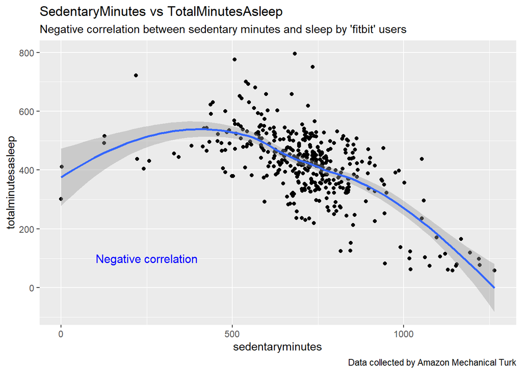

```r
ggplot(data = all_data_merged) +
  geom_point(mapping = aes(x=sedentaryminutes, y=totalminutesasleep))+
  geom_smooth(mapping = aes(x=sedentaryminutes, y=totalminutesasleep))+
  labs(title = "SedentaryMinutes vs TotalMinutesAsleep", subtitle = "Negative correlation between sedentary minutes and sleep by 'fitbit' users", caption="Data collected by Amazon Mechanical Turk")+
  annotate("text", x=250, y=100, label="Negative correlation", color="blue", size=4)
```

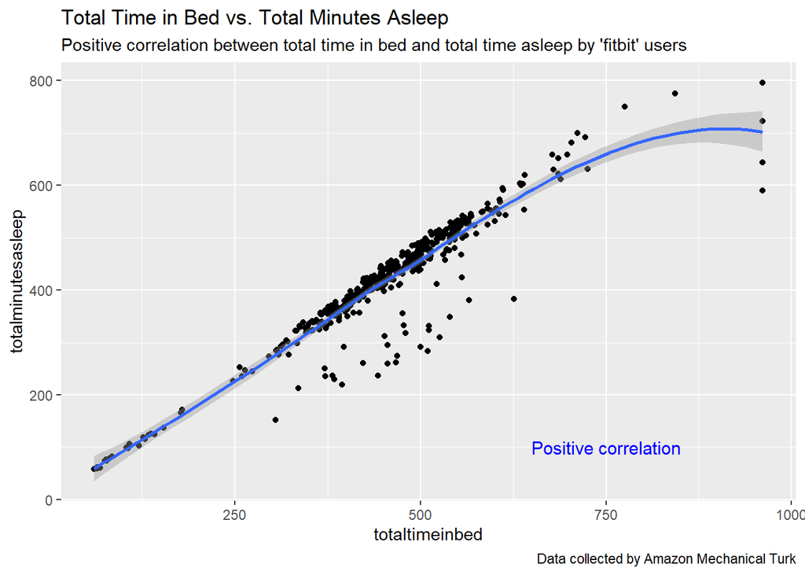

```r
ggplot(data = sleep) +
  geom_point(mapping = aes(x=totaltimeinbed, y=totalminutesasleep)) +
  geom_smooth(mapping = aes(x=totaltimeinbed, y=totalminutesasleep)) +
  labs(title="Total Time in Bed vs. Total Minutes Asleep", subtitle = "Positive correlation between total time in bed and total time asleep by 'fitbit' users", caption="Data collected by Amazon Mechanical Turk")+
  annotate("text", x=750, y=100, label="Positive correlation", color="blue", size=4)
```

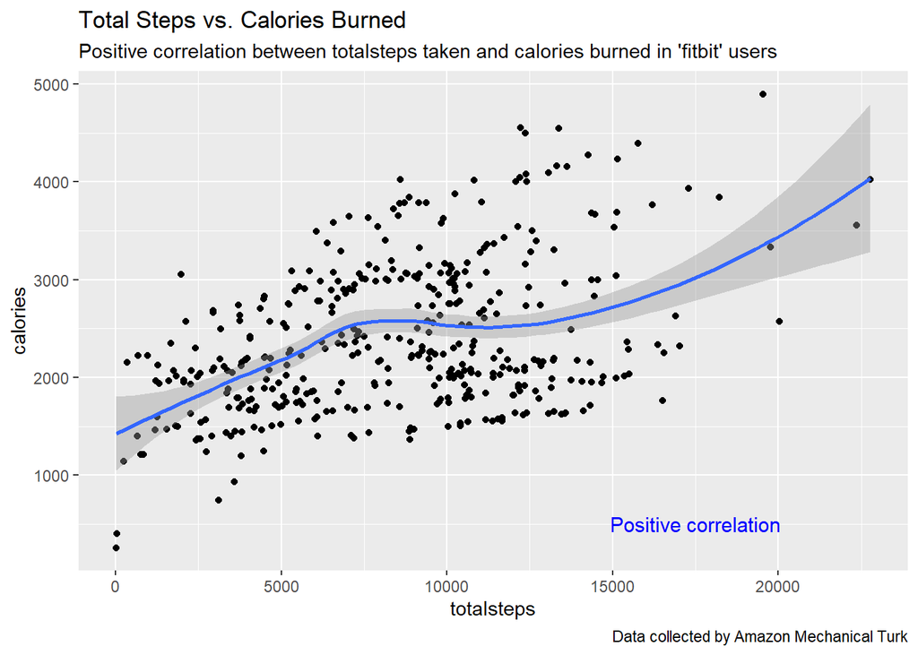

```r
ggplot(data = all_data_merged) +
  geom_point(mapping = aes(x=totalsteps, y=calories)) +
  geom_smooth(mapping = aes(x = totalsteps, y=calories)) +
  labs(title="Total Steps vs. Calories Burned", subtitle = "Positive correlation between totalsteps taken and calories burned in 'fitbit' users", caption="Data collected by Amazon Mechanical Turk")+
  annotate("text", x=17500, y=500, label="Positive correlation", color="blue", size=4)
```

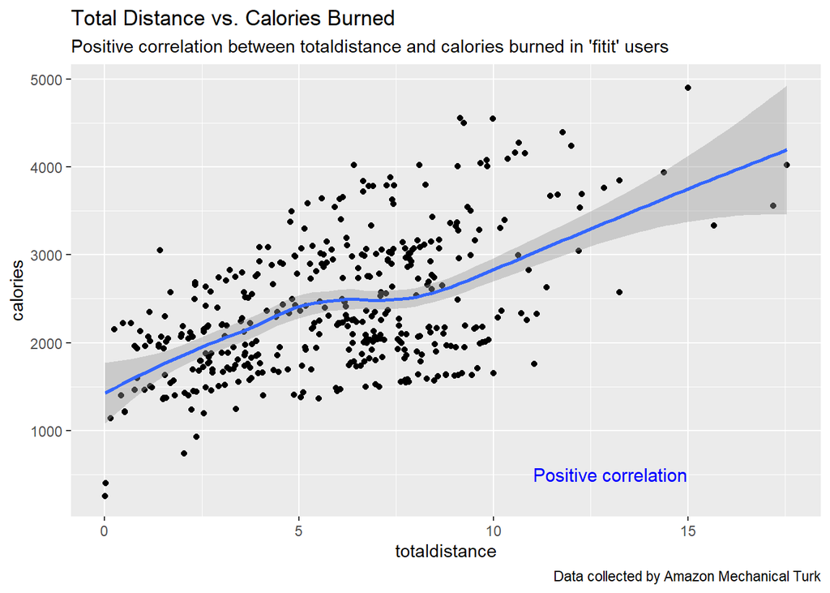

```r
ggplot(data = all_data_merged) +
  geom_point(mapping = aes(x=totaldistance, y=calories)) +
  geom_smooth(mapping = aes(x=totaldistance, y=calories)) +
  labs(title="Total Distance vs. Calories Burned", subtitle ="Positive correlation between totaldistance and calories burned in 'fitit' users", caption="Data collected by Amazon Mechanical Turk")+
  annotate("text", x=13, y=500, label="Positive correlation", color="blue", size=4)
```

**Activities and calorie burns weekly**

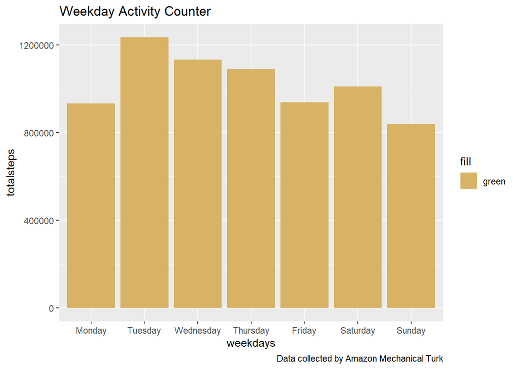

```r
activity %>%
  mutate(weekdays = weekdays(date)) %>%
  select(weekdays, totalsteps) %>%
  mutate(weekdays = factor(weekdays, levels = c('Monday', 'Tuesday', 'Wednesday', 'Thursday', 'Friday', 'Saturday', 'Sunday'))) %>%
  drop_na() %>%
  ggplot()+
  geom_col(mapping = aes(x=weekdays, y=totalsteps, fill='green'))+
  scale_fill_brewer(palette="BrBG")+
  labs(title = "Weekday Activity Counter", caption ="Data collected by Amazon Mechanical Turk")
```

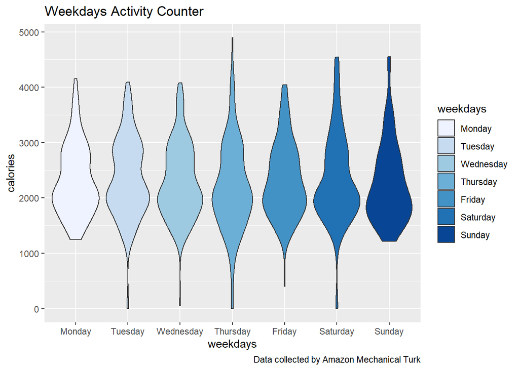

```r
activity %>%
  mutate(weekdays = weekdays(date)) %>%
  select(weekdays, calories) %>%
  mutate(weekdays = factor(weekdays, levels = c('Monday', 'Tuesday', 'Wednesday', 'Thursday', 'Friday', 'Saturday', 'Sunday'))) %>%
  drop_na() %>%
  ggplot()+
  geom_violin(mapping = aes(x=weekdays, y=calories, fill=weekdays))+
  scale_fill_brewer()+
  labs(title = "Weekdays Activity Counter", caption ="Data collected by Amazon Mechanical Turk")
```

**Time asleep per day**

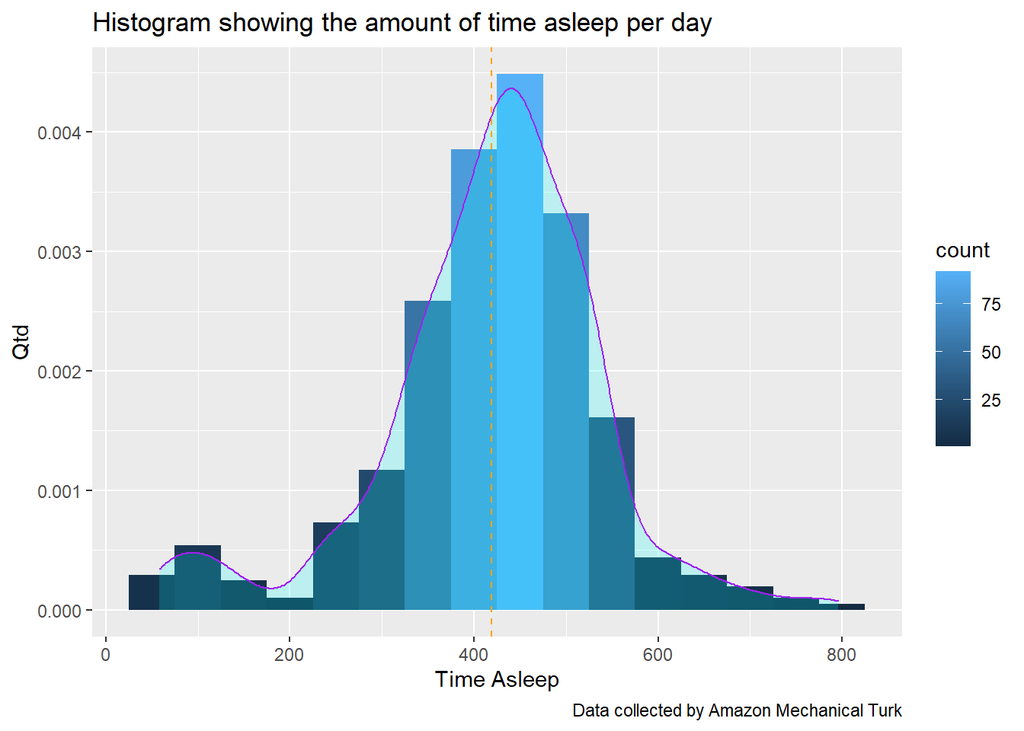

```r
ggplot(sleep, aes(totalminutesasleep))+
  geom_histogram(aes(y=..density.., fill = ..count..), binwidth=50)+
  geom_density(color= "purple", alpha=0.2, fill="cyan") +
  geom_vline(aes(xintercept=mean(totalminutesasleep, na.rm=T)),
             color="orange",
             linetype="dashed")+
  labs(title = "Histogram showing the amount of time asleep per day",
       caption = "Data collected by Amazon Mechanical Turk",
       x= "Time Asleep", y= "Qtd")
```

```r
sleepactivity <- merge(activity, sleep)
```

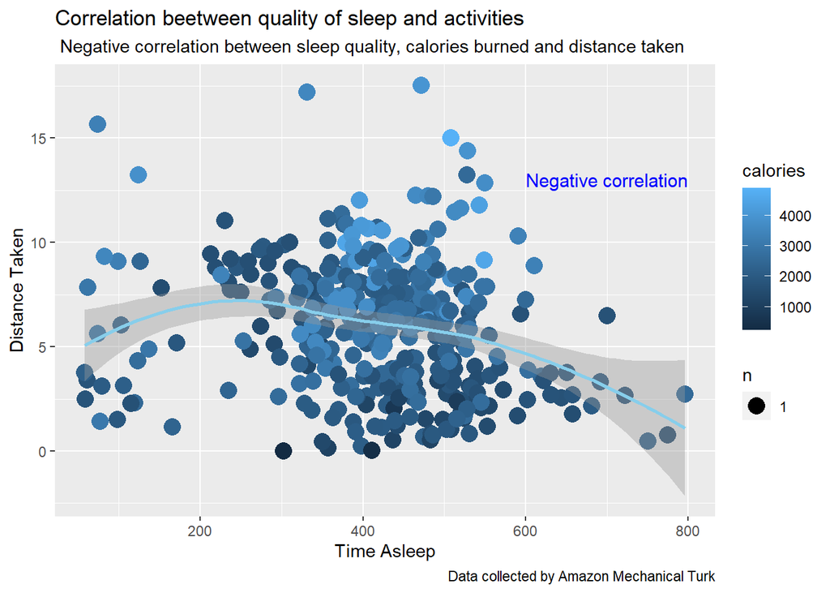

```r
ggplot(data = sleepactivity, aes(x= totalminutesasleep, y= totaldistance, fill = calories))+
geom_count( mapping = aes(color = calories)) +
geom_smooth(color = "skyblue") +
labs(title = "Correlation beetween quality of sleep and activities",
       subtitle = " Negative correlation between sleep quality, calories burned and distance taken",
       caption = "Data collected by Amazon Mechanical Turk" ,
       x= "Time Asleep", y= "Distance Taken") +
  annotate("text", x=700, y=13, label="Negative correlation", color="blue", size=4)
```

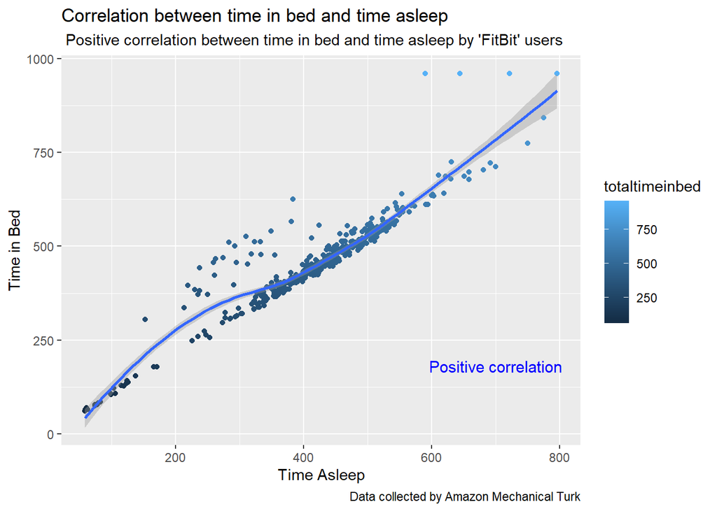

```r
ggplot(data = sleep,
         aes(x = totalminutesasleep, y = totaltimeinbed))+
geom_point(mapping = aes(color = totaltimeinbed)) +
geom_smooth(method="loess")+
labs(title = "Correlation between time in bed and time asleep",
         subtitle = " Positive correlation between time in bed and time asleep by 'FitBit' users ",
         caption = "Data collected by Amazon Mechanical Turk",
         x= "Time Asleep", y= "Time in Bed") +
    annotate("text", x=700, y=180, label="Positive correlation", color="blue", size=4)
```

```r
active_day <- activity %>% data.frame(
  group = c("lightlyactiveminutes"="Lightly Active",
            "fairlyactiveminutes"= "Fairly Active",
            "veryactiveminutes" = "Very Active",
            "sedentaryminutes" = "Zero activity"),
  value = c(sum(activity$lightlyactiveminutes)/1145628,
            sum(activity$fairlyactiveminutes)/1145628,
            sum(activity$veryactiveminutes)/1145628,
            sum(activity$sedentaryminutes)/1145628))
```

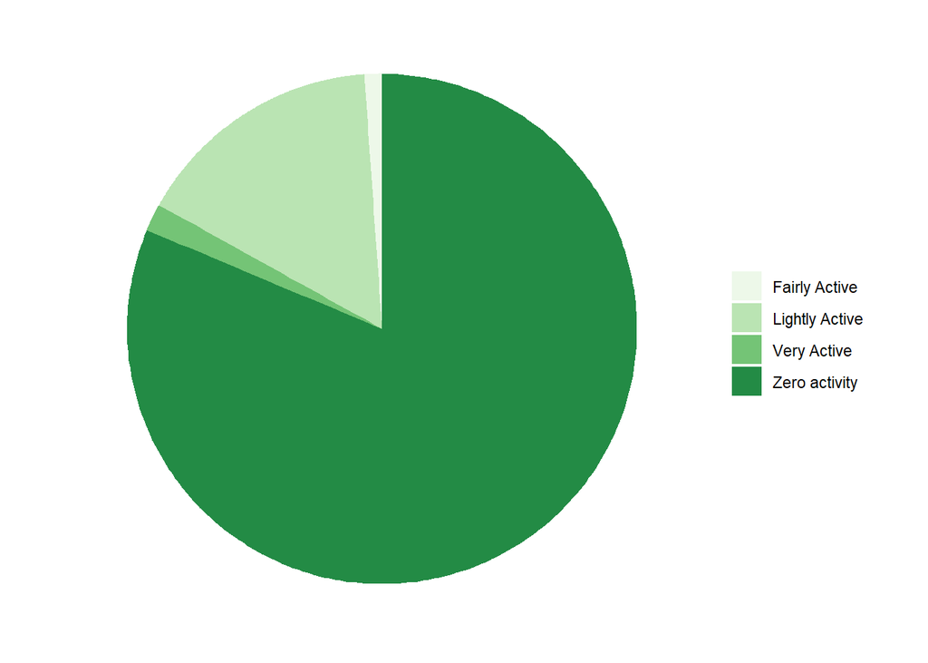

```r
ggplot(active_day, aes(x="", y=value, fill=group))+
  geom_bar(width = 1, stat = "identity")+
  coord_polar("y", start=0)+
  scale_fill_brewer(palette="BrBg")+
  theme_minimal()+
  theme(
    axis.title.x = element_blank(),
    axis.title.y = element_blank(),
    panel.border = element_blank(),
    panel.grid=element_blank(),
    axis.ticks = element_blank(),
    plot.title=element_text(size=14, face="bold"))+
  theme(axis.text.x=element_blank())+
  theme(legend.title = element_blank())
```

```r
activity_percent <-activity %>% data.frame(
  group = c("lightlyactiveminutes"="Lightly Active",
            "fairlyactiveminutes"= "Fairly Active",
            "veryactiveminutes" = "Very Active",
            "sedentaryminutes" = "Zero activity"),
  value = c(label_percent()(sum(activity$lightlyactiveminutes)/1145628),
            label_percent()(sum(activity$fairlyactiveminutes)/1145628),
            label_percent()(sum(activity$veryactiveminutes)/1145628),
            label_percent()(sum(activity$sedentaryminutes)/1145628)))
```

[figure not shown]

```r
ggplot(activity_percent, aes(x= group, y= value, fill= value))+
  geom_col()+
  geom_text(aes(y= value, label = value),
            size=5, color = "black", family = "Times new roman" ,
            vjust = -2.1)+
  theme_minimal()+
  scale_fill_brewer(palette = "BrBg")+
  theme(legend.position="none")+
  labs(title = "Activity analysis", x = "Activity Groups", y = "minutes",
       caption = "Data collected by Amazon Mechanical Turk")
```